# Progetto Modelli Statistici

Abdula Kalus

a.a. 2023/2024

## Analisi dei dati sulle mancie

Il dataset in **tips.csv** contiene infromazioni registrate da un cameriere sulle mancie ricevute in un periodo di qualche mese. Obiettivo dell’analisi è investigare la relazione tra il valore della mancia e le caratteristiche presenti nel dataset. Carichiamo i dati e guardiamo le prime righe della matrice dei dati

Dataset head

| total_bill | tip | sex | smoker | day | time | size |
| --- | --- | --- | --- | --- | --- | --- |
| 16.99 | 1.01 | Female | No | Sun | Dinner | 2 |
| 10.34 | 1.66 | Male | No | Sun | Dinner | 3 |
| 21.01 | 3.50 | Male | No | Sun | Dinner | 3 |
| 23.68 | 3.31 | Male | No | Sun | Dinner | 2 |
| 24.59 | 3.61 | Female | No | Sun | Dinner | 4 |
| 25.29 | 4.71 | Male | No | Sun | Dinner | 4 |

Il dataset è composto da 7 variabili e 244 osservazioni.

La variabile **y** è **tip**, e avrà il ruolo di variabile risposta.

- **tip**: mancia

Riportiamo sotto il significato delle variabili esplicative

1. **total_bill**: conto totale
2. **sex**: sesso del cliente ( *Male* o *Female* )
3. **smoker**: cliente fumaotre ( *si* o *no*)
4. **day**: giorno della settimana
5. **time**: orario del servizio ( *Lunch* o *Dinner*)
6. **size**: numero di persone

### Analisi esplorativa

Summary

|  | total_bill | tip | sex | smoker | day | time | size |
| --- | --- | --- | --- | --- | --- | --- | --- |
|  | Min. : 3.07 | Min. : 1.000 | Female: 87 | No :151 | Fri :19 | Dinner:176 | Min. :1.00 |
|  | 1st Qu.:13.35 | 1st Qu.: 2.000 | Male :157 | Yes: 93 | Sat :87 | Lunch : 68 | 1st Qu.:2.00 |
|  | Median :17.80 | Median : 2.900 |  |  | Sun :76 |  | Median :2.00 |
|  | Mean :19.79 | Mean : 2.998 |  |  | Thur:62 |  | Mean :2.57 |
|  | 3rd Qu.:24.13 | 3rd Qu.: 3.562 |  |  |  |  | 3rd Qu.:3.00 |
|  | Max. :50.81 | Max. :10.000 |  |  |  |  | Max. :6.00 |

Possiamo vedere dalla tabella riassuntiva ottenuta con il comando *summary* alcune sintesi statistiche sul dataset, sono presenti tre variabili continue ( *total_bill*, *tip*, *size* ) e quattro varibile categoriali ( *sex*, *smoker*, *day*, *time*). Inoltre possiamo osservare che non è segnalata la presenza di valori NA.

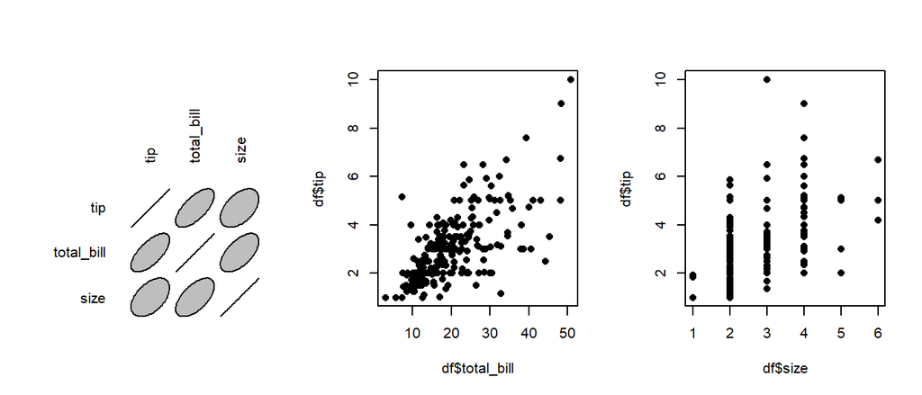

Dal grafico rappresentante la correlazione tra le variabili quantitaitve possiamo vedere che ci sono delle buone correlazioni tra la variabile risposta e le variabili esplicative, tuttavia anche le due variaibili esplicative sono correlate tra di loro. Osseravando il grafico di dispersione della variabile size è stato deciso di convertirla da numerica a fattore.

### Diagramma di dispersione in base ai gruppi delle variabili qualitative

Per osservare se nel grafico di dipsersione tra le mancie ed il conto toale sono presenti dei pattern tra i gruppi delle variabili qualitative, si osservino i grafici seguenti

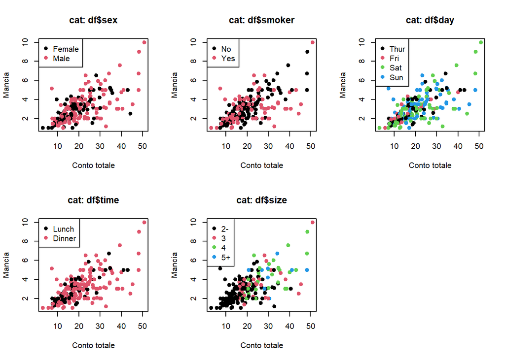

Possiamo osservare che non sono presenti dei pattern nei diagrammi di dispersione rispetto alle rispettive variabili qualitative, i dati risultano distribuiti in modo omogeneo.

### Panoramica delle variabili

I grafici seguenti mostrano delle carattersitche generali delle varaibili, in particolar modo:

- la frequenza di ciascun gruppo nelle varie variabili esplicative
- la distribuzione della variabile **tip** e __total__bill__

Si puo osservare dalle frequenze che:

- gli uomini tendono a dare più spesso la mancia
- analogo per i non fumatori
- la maggiro parte delle mancie è data durante gli weekend
- la maggiro parte delle mancie è data durante le cene
- la maggior parte delle mancie è data dai tavoli meno numerosi

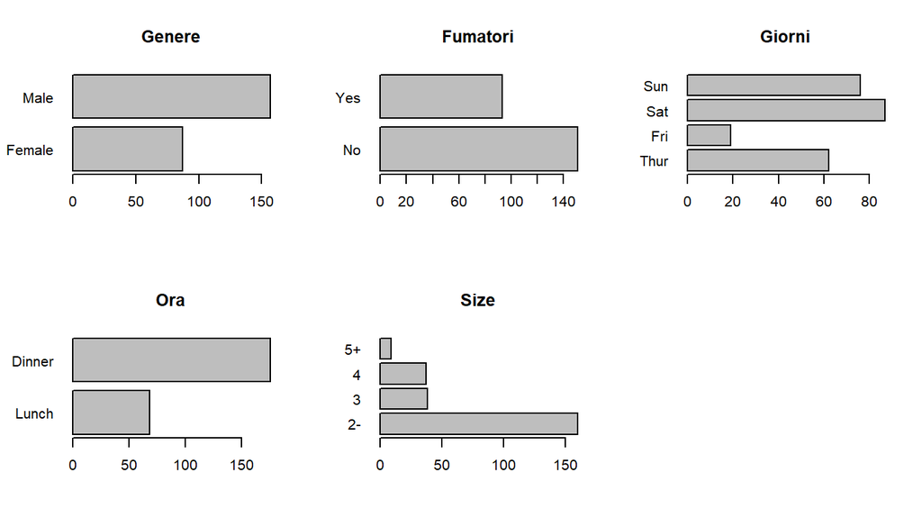

Per quanto riaguarda la distribuzione delle mancie si può notare che è decisamente asimmetrica. Questo si riflette sulla distribuzione dei residui del modello lineare per gli incassi. Per questo motivo viene proposta una trasformazione logaritimica e una sotto radice. La trasformazione logaritmica e radice appare, almeno marginalmente, normalizzante.

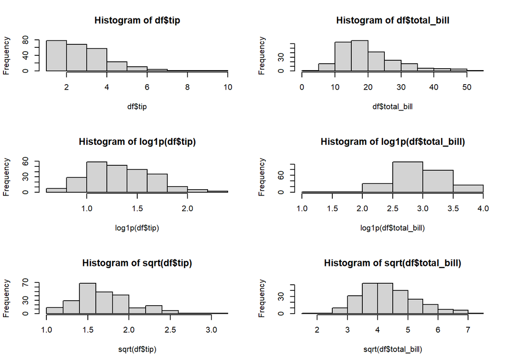

Nel seguente modello possiamo constatare l’osservazioen precedente ovvero che il modello senza nessuna trasformazione non rispetta l’omoschedasticità e la normalità.

```r
fit_nT <- lm(tip ~ total_bill, data = df)
```

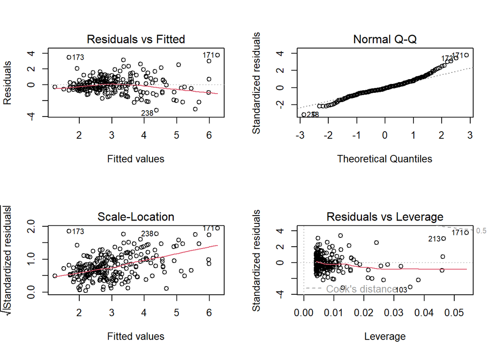

E’ opportuna perciò adottare una delle trasformazione proposte, dopo alcune analisi preliminari risultano soddisfacenti il passaggio al logaritmo o alla radice.

### Creazione del modello

Dai seguenti grafici possiamo vedere che le due trasformazioni hanno un effetto positivo sul grafico di dispersione e sulle dsitribuzioni delle variabili.

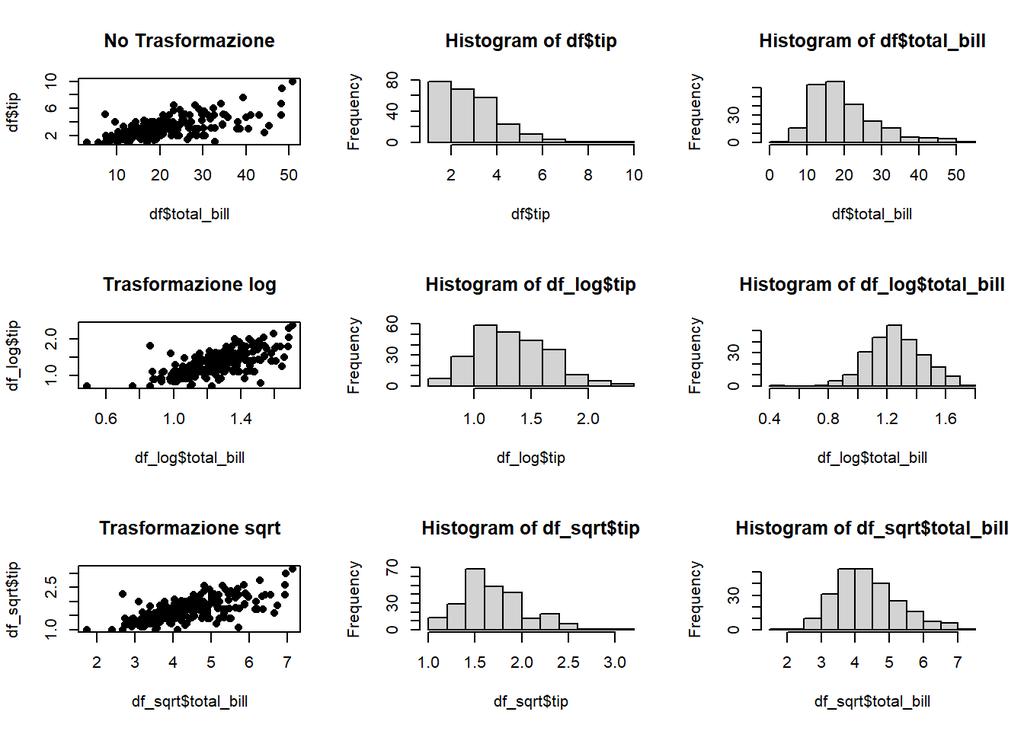

#### fit_lA & fit_sA

I primi due modelli sono dei modelli semplici tra la variabile esplicativa **total_bill** e la varaibile risposta **tip** con le rispettive trasformazioni:

- **fit_lA** modello log
- **fit_sA** modello sqrt

```r
par(mfrow=c(1,2))
fit_lA <- lm(tip ~ total_bill, data = df_log)
fit_sA <- lm(tip ~ total_bill, data = df_sqrt)
```

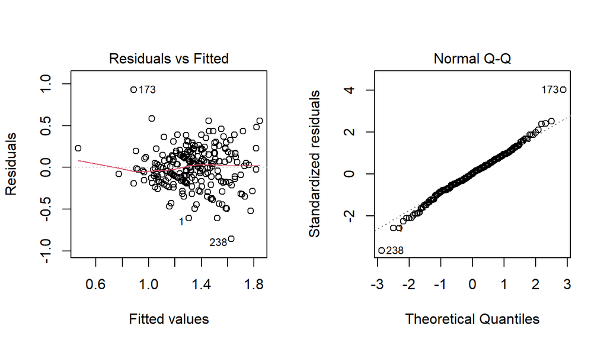

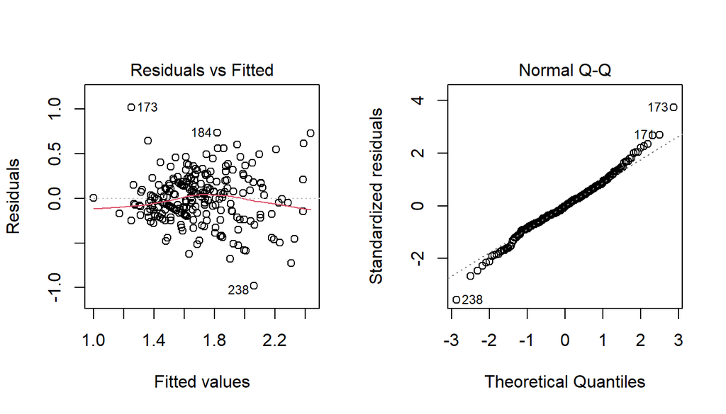

Si ha che la variabile **total_bill** ha un effetto signficativo e positivo sulla variabile risposta **tip**, nel senso che quest’ultimo cresce al crescere del conto totale.

Inoltre dal grafico dei residui possiamo osservare che nessuno dei due modelli ha un grafico di dispersione ideale, non è rispettata appieno l’omoschedasticità, invece dal **qq-plot** osserviamo che sulle che la normalità non molto rispettata.

#### Summary modello fit_lA

```
##
## Call:
## lm(formula = tip ~ total_bill, data = df_log)
##
## Residuals:
##      Min       1Q   Median       3Q      Max
## -0.85404 -0.13198  0.00283  0.14743  0.92969
##
## Coefficients:
##             Estimate Std. Error t value Pr(>|t|)
## (Intercept) -0.08648    0.10011  -0.864    0.389
## total_bill   1.13123    0.07885  14.347   <2e-16 ***
## ---
## Signif. codes:  0 '***' 0.001 '**' 0.01 '*' 0.05 '.' 0.1 ' ' 1
##
## Residual standard error: 0.2343 on 242 degrees of freedom
## Multiple R-squared:  0.4596, Adjusted R-squared:  0.4574
## F-statistic: 205.8 on 1 and 242 DF,  p-value: < 2.2e-16
```

Dal summary del modelli possiamo vedere che:

- l’intercetta nel modello è negativo (un valore **non** realistico)
- solamente il secondo coefficenti risulta statisticamente significativo
- con un $R^{2}$ pari a 0.4574 si ha che la percentuale di variabilità spiegata dal modello è buona

#### Summary modello fit_sA

```
##
## Call:
## lm(formula = tip ~ total_bill, data = df_sqrt)
##
## Residuals:
##      Min       1Q   Median       3Q      Max
## -0.97853 -0.16729 -0.00683  0.16039  1.01971
##
## Coefficients:
##             Estimate Std. Error t value Pr(>|t|)
## (Intercept)  0.53106    0.08239   6.445 6.19e-10 ***
## total_bill   0.26688    0.01852  14.408  < 2e-16 ***
## ---
## Signif. codes:  0 '***' 0.001 '**' 0.01 '*' 0.05 '.' 0.1 ' ' 1
##
## Residual standard error: 0.2759 on 242 degrees of freedom
## Multiple R-squared:  0.4617, Adjusted R-squared:  0.4595
## F-statistic: 207.6 on 1 and 242 DF,  p-value: < 2.2e-16
```

per quanto rigiarda il secondo modello:

- l’intercetta è positivo
- entrambi i coefficenti risultano statisticamente significativi nel secondo modello
- con un $R^{2}$ pari a 0.4595 si ha che la percentuale di variabilità spiegata dal modello è buona

#### fit_sB

```r
fit_sB <- lm(tip ~ size, data = df_sqrt)
```

```
##
## Call:
## lm(formula = tip ~ size, data = df_sqrt)
##
## Residuals:
##      Min       1Q   Median       3Q      Max
## -0.69640 -0.23229  0.00295  0.19584  1.35812
##
## Coefficients:
##             Estimate Std. Error t value Pr(>|t|)
## (Intercept)  1.56921    0.02618  59.931  < 2e-16 ***
## size3        0.23494    0.05977   3.931 0.000111 ***
## size4        0.42730    0.06042   7.072 1.66e-11 ***
## size5+       0.54140    0.11346   4.772 3.18e-06 ***
## ---
## Signif. codes:  0 '***' 0.001 '**' 0.01 '*' 0.05 '.' 0.1 ' ' 1
##
## Residual standard error: 0.3312 on 240 degrees of freedom
## Multiple R-squared:  0.2308, Adjusted R-squared:  0.2211
## F-statistic:    24 on 3 and 240 DF,  p-value: 1.282e-13
```

dal summary possiamo vedere che:

- l’intercetta è positivo
- tutti i coefficenti risultano statisticamente significativi
- si ha un $R^{2}$ pari a 0.2211, minore rispetto al modello **fit_sA**

```
## Analysis of Variance Table
##
## Response: tip
##            Df  Sum Sq Mean Sq F value    Pr(>F)
## size        3  7.8978 2.63261  23.999 1.282e-13 ***
## Residuals 240 26.3268 0.10969
## ---
## Signif. codes:  0 '***' 0.001 '**' 0.01 '*' 0.05 '.' 0.1 ' ' 1
```

I risultati del test mostrano chiaramente che non vi è evidenza per ritenere che tutte le medie siano uguali (o equivalentemente che i coefficienti $\beta_{j}$ , j = 2, . . . , 5 siano congiuntamente pari a zero)

#### fit_sAB

```r
fit_sAB <- lm(tip ~ total_bill + size, data = df_sqrt)
```

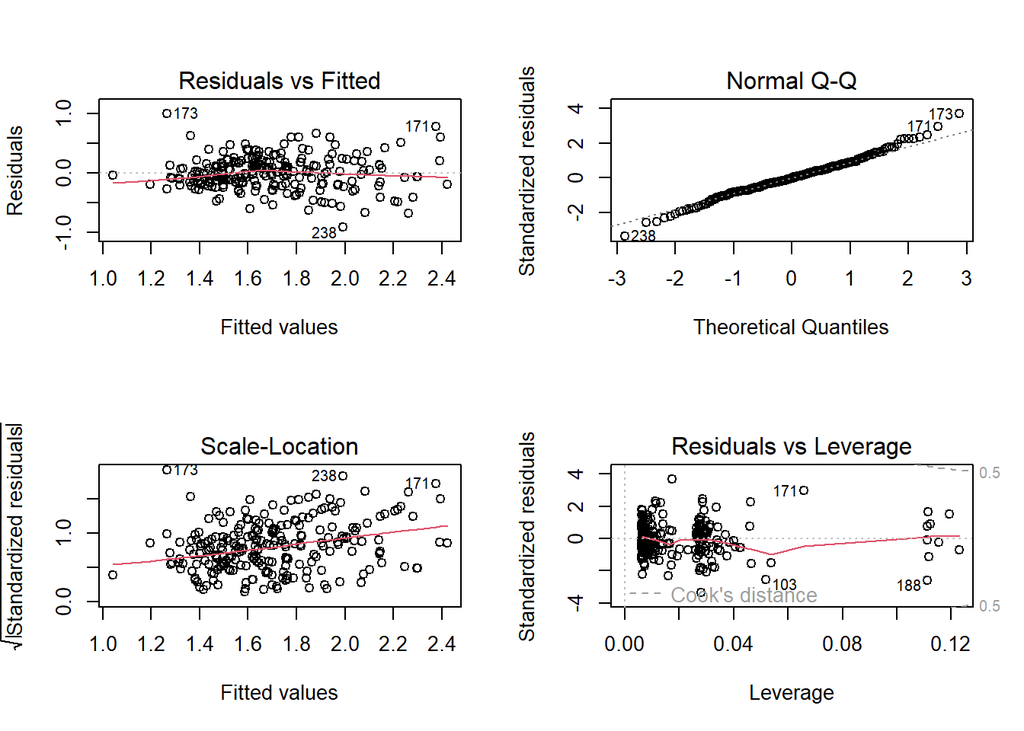

#### Summary fit_sAB

```
##
## Call:
## lm(formula = tip ~ total_bill + size, data = df_sqrt)
##
## Residuals:
##      Min       1Q   Median       3Q      Max
## -0.91091 -0.17078 -0.00947  0.16065  1.00297
##
## Coefficients:
##             Estimate Std. Error t value Pr(>|t|)
## (Intercept)  0.62259    0.09338   6.667 1.79e-10 ***
## total_bill   0.23910    0.02294  10.424  < 2e-16 ***
## size3        0.04817    0.05279   0.912   0.3624
## size4        0.10849    0.05878   1.846   0.0662 .
## size5+       0.14077    0.10181   1.383   0.1680
## ---
## Signif. codes:  0 '***' 0.001 '**' 0.01 '*' 0.05 '.' 0.1 ' ' 1
##
## Residual standard error: 0.2752 on 239 degrees of freedom
## Multiple R-squared:  0.4712, Adjusted R-squared:  0.4623
## F-statistic: 53.24 on 4 and 239 DF,  p-value: < 2.2e-16
```

dal summary possiamo vedere che:

- l’intercetta è positivo
- solamente il coefficente **total_bill** risulta statisticamente significativo
- si ha un $R^{2}$ pari a 0.4623, poco maggiore rispetto al modello **fit_sA**, la complessità è aumentata di molto tuttavia il tradeoff non è vantaggioso

### Scelta del modello

```
##                          R2_adj       AIC        BIC
## log(total_bill)       0.4573789 -11.77823  -1.286721
## sqrt(total_bill)      0.4594946  68.04409  78.535593
## size                  0.2211495 159.15589 176.641730
## sqrt(total_bill)+size 0.4623227  69.72032  90.703328
```

Si può osservare che il modello con $R^{2}_{adj}$ più elevato è l’ultimo, tuttavia non va considerato il modello migliroe in quanto la complessità di tale modello è più elevata rispetto agli altri, ed in confronto al modello **sqrt(total_bill)** la variabilità spiegata non è drasticamente più elevata, inoltre bisogna ricordare che solo il coefficente **total_bill** è siginficativa in quel modello invece gli altri no.

Per la nota precedente escludiamo la trasforamzione logaritmica per il confronto dei modelli con i test **AIC** e **BIC**, osservando i valori questi due test per i modelli restanti vediamo che i valori minori per entrambi i test corrispondono al modello **sqrt(total_bill)**.

Il modello con il logaritmo non viene considerato perchè ha un intercetta negativo e non significativo per questo motivo giungiamo alla conlcusione che il modello migliore deve essere uno di quelli con la trasformazione **sqrt**.

Quindi il modello scelto dopo tutte le considerazione precedenti è **sqrt(total_bill)**.